# Incarceration rate in the US

Trang Tran

02/25/2022

# Summary

The unjust mass incarceration of the US that backed a massive prison industrial complex masks under political righteousness of “the war on drugs” to uphold the systemic racism. When the system’s core focus is not on the safety of the people and the greater good of society, but on the benefits of the powerful and wealthy few, the reality is unsettling. According to the documentation “The 13th”, the US accounts for only 5% of the world’s population but 25% of the world’s prison population. One in four of the people that are locked-up is in America, the land of the free and the symbol of democracy. This statistic urges the questions of why and what has really been happening?

## The current project

In an effort of investigating what the picture of incarceration in the US looks like, this project uses the jail and prison population data set from the Vera Institutes for the analysis, which covers the period from 1970 to 2018. Specifically, the focal point rests on how systemic racism ties to the current mass incarceration in the US. Hence, the main variables of interest are the demographics of jail and prison population in terms of racial identity and the corresponding proportion to the general population. The data showed that the average black prison population each year is 2.57731^{5}, while the average white prison population each year is 2.10709^{5}. These numbers would be not alarming, had it not been clear that White people accounts for the majority of the US population, while Black population is the exact opposite. Moreover, the largest prison population in a year is 1.2608786^{6}; the largest prison population over total population in a year is 0.007, which means 7 out of 1000 people were incarcerated.

# Trend lines

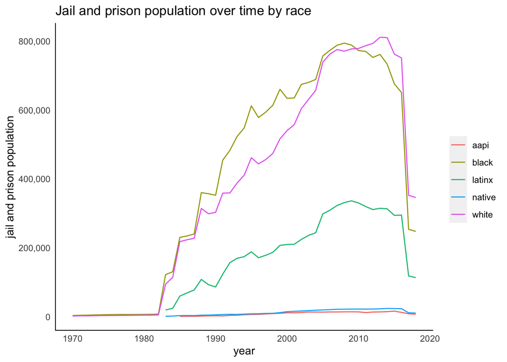

# Comparison

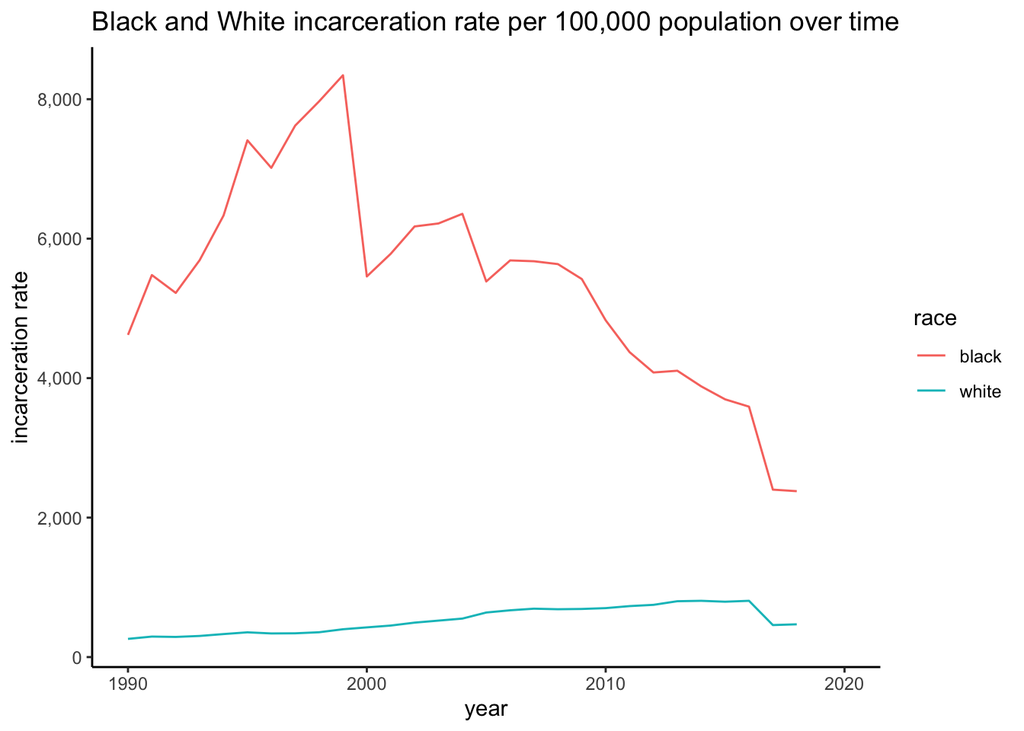

# Map

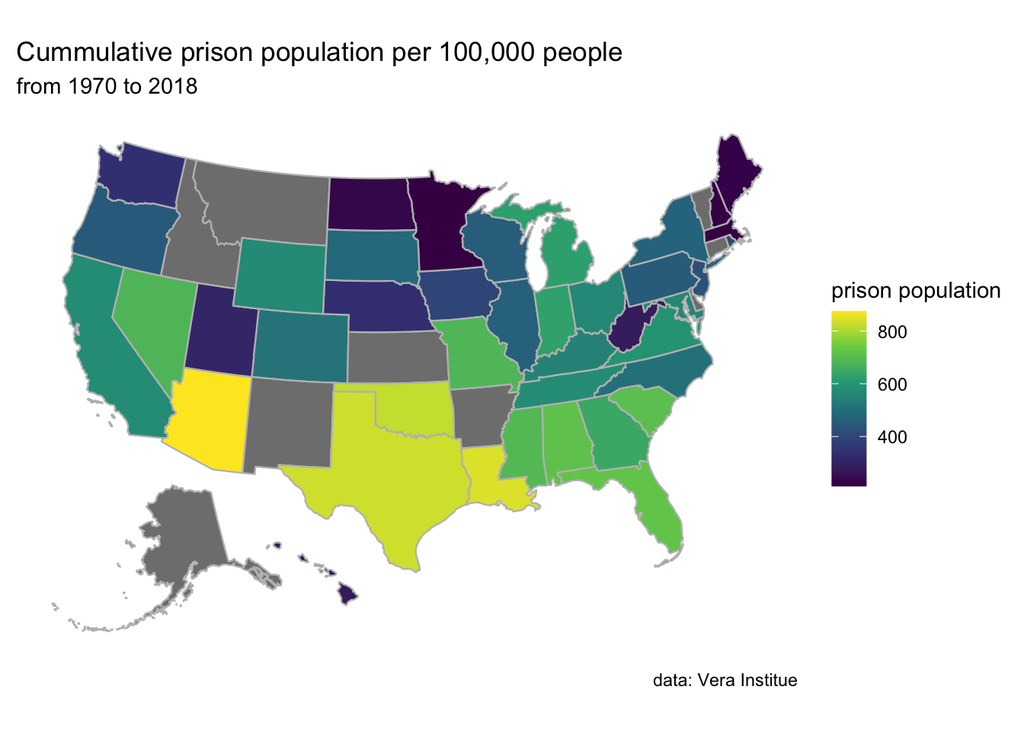